# Patent Abstracts — Bigram Word Cloud

## 4b — Fetch abstracts from OPS

We query the *published-data* endpoint one patent at a time. OPS anonymous throttle is ~4 req/s; we add a small delay to be polite.

```r
ns <- c(ex = "http://www.epo.org/exchange", ops = "http://ops.epo.org")

extract_en_abstract <- function(doc) {
  abs_nodes <- xml_find_all(doc, ".//ex:abstract", ns)
  langs <- xml_attr(abs_nodes, "lang")
  en <- abs_nodes[!is.na(langs) & langs == "en"]
  node <- if (length(en) > 0) en[[1]] else NULL
  if (is.null(node)) return(NA_character_)

  p_nodes <- xml_find_all(node, ".//ex:p", ns)
  text <- if (length(p_nodes) > 0) paste(xml_text(p_nodes), collapse = " ") else xml_text(node)
  text <- str_squish(text)
  if (nchar(text) < 10) NA_character_ else text
}

extract_en_title <- function(doc) {
  title_nodes <- xml_find_all(doc, ".//ex:invention-title", ns)
  langs <- xml_attr(title_nodes, "lang")
  en <- title_nodes[!is.na(langs) & langs == "en"]
  node <- if (length(en) > 0) en[[1]] else NULL
  if (is.null(node)) return(NA_character_)
  str_squish(xml_text(node))
}

fetch_patent <- function(country, docnumber, token) {
  epodoc <- paste0(country, ".", docnumber)
  abstract <- NA_character_
  title    <- NA_character_

  # Helper to try one URL and extract abstract + title
  try_endpoint <- function(url) {
    resp <- request(url) |>
      req_headers(Authorization = paste("Bearer", token),
                  Accept        = "application/xml") |>
      req_error(is_error = \(resp) FALSE) |>
      req_perform()
    if (resp_status(resp) >= 400) return(NULL)
    resp_body_xml(resp)
  }

  # --- Step 1: direct application endpoint (biblio for title + abstract) ---
  tryCatch({
    doc <- try_endpoint(paste0(
      "https://ops.epo.org/3.2/rest-services/published-data/application/epodoc/",
      epodoc, "/biblio,abstract"
    ))
    if (!is.null(doc)) {
      abstract <- extract_en_abstract(doc)
      title    <- extract_en_title(doc)
    }
  }, error = function(e) NULL)

  # --- Step 2: family fallback if no English abstract ---
  if (is.na(abstract)) {
    tryCatch({
      Sys.sleep(0.3)
      doc <- try_endpoint(paste0(
        "https://ops.epo.org/3.2/rest-services/family/application/epodoc/",
        epodoc, "/biblio,abstract"
      ))
      if (!is.null(doc)) {
        abstract <- extract_en_abstract(doc)
        if (is.na(title)) title <- extract_en_title(doc)
      }
    }, error = function(e) NULL)
  }

  src <- if (!is.na(abstract)) "OK" else "miss"
  message("  [", src, "] ", epodoc,
          if (!is.na(title)) paste0(" — ", str_trunc(title, 60)) else "")

  tibble(title = title, abstract = abstract)
}

results <- parsed |>
  mutate(data = map2(country, docnumber, \(cc, dn) {
    Sys.sleep(0.3)
    fetch_patent(cc, dn, access_token)
  })) |>
  unnest(data)
```

```
##   [OK] CN.201810134850 — Stable heterodimeric antibody design with mutations in th...
```

```
##   [miss] PT.12858932
```

```
##   [OK] US.89428710 — Location-based Coupons and Mobile Devices
```

```
##   [OK] US.201414220990 — Aerial farm robot system for crop dusting, planting, fert...
```

```
##   [miss] ARP.120101066
```

```
##   [OK] EP.09305250 — Optimized Fc variants
```

```
##   [OK] CA.3117920 — LIBRARIES COMPRISING SEGMENTAL POOLS, AND METHODS FOR THE...
```

```
##   [miss] SG.11201506775V — CONTINUOUS PURIFICATION OF THERAPEUTIC PROTEINS
```

```
##   [miss] EP.11833120 — DEVICE FOR HIGH THROUGHPUT INVESTIGATIONS OF CELLULAR INT...
```

```
##   [miss] KR.20207024776 — 6- MICROORGANISMS AND METHODS FOR THE BIOSYNTHESIS OF ADI...
```

```
##   [OK] AU.2011349446 — Cell culture platform for single cell sorting and enhance...
```

```
##   [OK] US.201213679498 — VIRTUAL DRESSING ROOM
```

```
##   [miss] BR.112013025572
```

```
##   [OK] KR.20127020023 — SWEETNESS ENHANCERS, COMPOSITIONS THEREOF, AND METHODS FO...
```

```
##   [OK] CN.201380028604 — Targeted/immunomodulatory fusion proteins and methods for...
```

```
##   [OK] US.59260509 — Automated modular and secure boot firmware update
```

```
##   [OK] US.201114008192 — Method and System for Dynamically Publishing, Sharing, Co...
```

```
##   [OK] US.76340110 — Role Based Game Play on a Social Network
```

```
##   [OK] MX.2014002289 — TANDEM FC BISPECIFIC ANTIBODIES.
```

```
##   [miss] WO.2011039386
```

```
##   [miss] WO.2011021301
```

```
##   [miss] HUE.16193906
```

```
##   [miss] WO.2009007269
```

```
##   [OK] US.201414293546 — DATAFLOW ALERTS FOR AN INFORMATION MANAGEMENT SYSTEM
```

```
##   [OK] US.201113107352 — SYSTEMS AND METHODS FOR PROVIDING MOBILE TARGETED ADVERTI...
```

```
##   [OK] US.201314425505 — METHODS OF TISSUE GENERATION
```

```
##   [miss] SG.10201504187Y — TAILORED OILS PRODUCED FROM RECOMBINANT HETEROTROPHIC MIC...
```

```
##   [OK] US.60981509 — Domain Traffic Ranking
```

```
##   [OK] US.201615193033 — Hybrid airship-drone farm robot system for crop dusting, ...
```

```
##   [miss] WO.2010003130
```

```
##   [miss] PL.13159003
```

```
##   [miss] BRPI.1002602
```

```
##   [miss] WO.2015033929
```

```
##   [miss] BRPI.1102284
```

```
##   [OK] AU.2015314826 — Cysteine engineered antibodies and conjugates
```

```
##   [OK] US.86898910 — SOYBEAN TRANSGENIC EVENT MON 87708 AND METHODS OF USE THE...
```

```
##   [miss] BR.112017009050
```

```
##   [miss] WO.2011038946
```

```
##   [OK] KR.20147016656 — SYSTEMS AND METHODS FOR COOKING WITH A SMARTCOOK ARCHITEC...
```

```
##   [OK] CN.201080049139 — Dual variable domain immunoglobulins and uses thereof
```

```
##   [miss] PL.11858867
```

```
##   [miss] AU.2013360086 — Botanical antimicrobial compositions
```

```
##   [miss] ES.11728509
```

```
##   [miss] WO.2010000938
```

```
##   [OK] US.48126009 — SYSTEM AND METHOD OF AUTOMATED FAULT ANALYSIS AND DIAGNOS...
```

```
##   [miss] EP.13762719 — BANK NOTE PROTECTION
```

```
##   [OK] US.201313920673 — THREE-DIMENSIONAL COORDINATE SCANNER AND METHOD OF OPERATION
```

```
##   [OK] NZ.61861310 — Fungicide pyrazole carboxamides derivatives
```

```
##   [OK] MX.2011003856 — COMPOSITION OF SOLID LIPID NANOPARTICLES FOR THE LONG-TER...
```

```
##   [miss] ARP.110104677
```

```r
cat("\nFetched", sum(!is.na(results$abstract)), "abstracts and",
    sum(!is.na(results$title)), "titles out of",
    nrow(results), "applications\n")
```

```
##
## Fetched 26 abstracts and 32 titles out of 50 applications
```

```r
# Keep backward-compatible name for downstream chunks
abstracts <- results
```

## 5 — AI-derived innovation labels

For each patent we ask OpenAI to produce a short n-gram (2–5 words) that captures the core innovation, using both the title and the abstract.

````r
openai_key <- Sys.getenv("OPENAI_API_KEY", unset = "")
stopifnot("Set OPENAI_API_KEY in your .Renviron" = nchar(openai_key) > 0)

# Build a batch prompt — send all patents in one call for speed & cost
patent_block <- abstracts |>
  filter(!is.na(abstract) | !is.na(title)) |>
  mutate(entry = paste0(
    "[", row_number(), "] ",
    if_else(!is.na(title), paste0("Title: ", title, ". "), ""),
    if_else(!is.na(abstract), paste0("Abstract: ", str_trunc(abstract, 500)), "")
  )) |>
  pull(entry) |>
  paste(collapse = "\n\n")

label_prompt <- paste0(
 "Below are patents, each with a number in brackets, a title and/or abstract.\n\n",
  patent_block,
  "\n\n---\n",
  "For EACH patent, produce a short descriptive n-gram (2 to 5 words, lowercase) ",
  "that captures the core innovation or technology. ",
  "Do NOT use generic phrases like 'novel method' or 'improved system'. ",
  "Be specific and technical, e.g. 'antibody fc region engineering', ",
  "'lithium battery cathode recycling', 'crispr gene editing delivery'.\n\n",
  "Return ONLY a JSON array of objects with keys \"id\" (the bracket number) ",
  "and \"label\" (the n-gram). No other text."
)

label_resp <- request("https://api.openai.com/v1/chat/completions") |>
  req_headers(Authorization = paste("Bearer", openai_key),
              `Content-Type` = "application/json") |>
  req_body_json(list(
    model    = "gpt-4o-mini",
    messages = list(list(role = "user", content = label_prompt)),
    temperature = 0.2,
    max_tokens  = 2000
  )) |>
  req_perform()

raw_json <- resp_body_json(label_resp)$choices[[1]]$message$content

# Strip markdown code fences if present
raw_json <- str_remove_all(raw_json, "```json\\s*|```\\s*")

labels_df <- jsonlite::fromJSON(raw_json) |>
  as_tibble() |>
  mutate(id = as.integer(id),
         label = str_to_lower(str_squish(label)))

# Attach back to the abstracts that were sent
sent <- abstracts |>
  filter(!is.na(abstract) | !is.na(title)) |>
  mutate(id = row_number())

labelled <- sent |>
  left_join(labels_df, by = "id")

cat("Labelled", sum(!is.na(labelled$label)), "patents\n")
````

```
## Labelled 32 patents
```

```r
labelled |> select(raw, label) |> print(n = 60)
```

```
## # A tibble: 32 × 2
##    raw            label
##    <chr>          <chr>
##  1 CN201810134850 heterodimeric antibody design
##  2 US89428710     location-based coupons
##  3 US201414220990 aerial farm robot
##  4 EP09305250     optimized fc variants
##  5 CA3117920      polypeptide library generation
##  6 SG11201506775V continuous protein purification
##  7 EP11833120     high throughput cellular investigations
##  8 KR20207024776  biosynthesis of adipate
##  9 AU2011349446   single cell sorting platform
## 10 US201213679498 virtual dressing room
## 11 KR20127020023  sweetness enhancer compositions
## 12 CN201380028604 targeted fusion proteins
```

[output cut: 20 more lines]

## 6 — AI-label word cloud

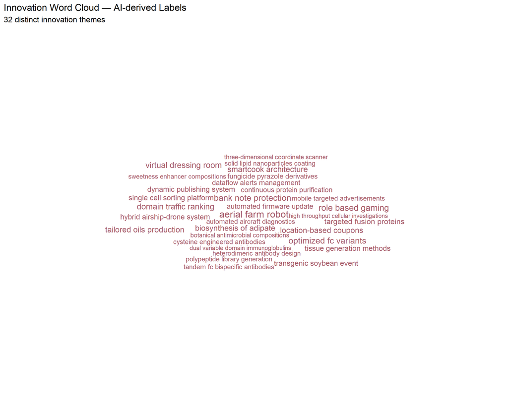

```r
label_counts <- labelled |>
  filter(!is.na(label)) |>
  count(label, sort = TRUE)

ggplot(label_counts, aes(label = label, size = n, colour = n)) +
  geom_text_wordcloud_area(rm_outside = TRUE, shape = "circle",
                           eccentricity = 0.65) +
  scale_size_area(max_size = 16) +
  scale_colour_gradient(low = "#2c7bb6", high = "#d7191c") +
  theme_minimal() +
  labs(title = "Innovation Word Cloud — AI-derived Labels",
       subtitle = paste(nrow(label_counts), "distinct innovation themes"))
```

## 7 — AI-label bar chart

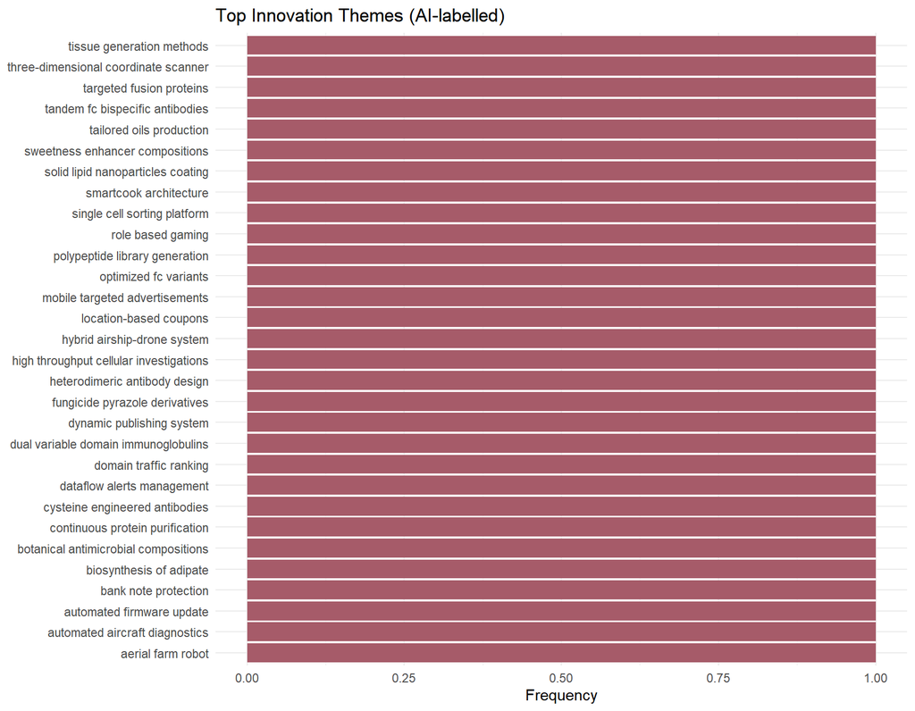

```r
label_counts |>
  slice_max(n, n = 30, with_ties = FALSE) |>
  mutate(label = reorder(label, n)) |>
  ggplot(aes(n, label, fill = n)) +
  geom_col(show.legend = FALSE) +
  scale_fill_gradient(low = "#2c7bb6", high = "#d7191c") +
  labs(x = "Frequency", y = NULL,
       title = "Top Innovation Themes (AI-labelled)") +
  theme_minimal()
```

## 8 — Statistical bigrams (original)

For reference, the traditional bigram word cloud from raw abstract text.

```r
custom_stop <- tibble(word = c("patent", "invention", "present", "method",
                               "comprises", "comprising", "device", "apparatus",
                               "provided", "relates", "described", "including",
                               "wherein", "thereof", "according"))

bigrams <- abstracts |>
  filter(!is.na(abstract)) |>
  select(raw, abstract) |>
  unnest_tokens(bigram, abstract, token = "ngrams", n = 2) |>
  separate(bigram, into = c("word1", "word2"), sep = " ", remove = FALSE) |>
  anti_join(stop_words, by = c("word1" = "word")) |>
  anti_join(stop_words, by = c("word2" = "word")) |>
  anti_join(custom_stop, by = c("word1" = "word")) |>
  anti_join(custom_stop, by = c("word2" = "word")) |>
  filter(!str_detect(word1, "\\d"), !str_detect(word2, "\\d"))

bigram_counts <- bigrams |>
  count(bigram, sort = TRUE)

head(bigram_counts, 20)
```

| bigram | n |
| --- | --- |
| boot firmware | 10 |
| firmware code | 9 |
| sweetness enhancer | 8 |
| code module | 7 |
| maintenance test | 7 |
| amino acid | 5 |
| automated farming | 5 |
| event mon | 5 |
| smart cook | 5 |
| updated boot | 5 |

[output cut: 10 more lines]

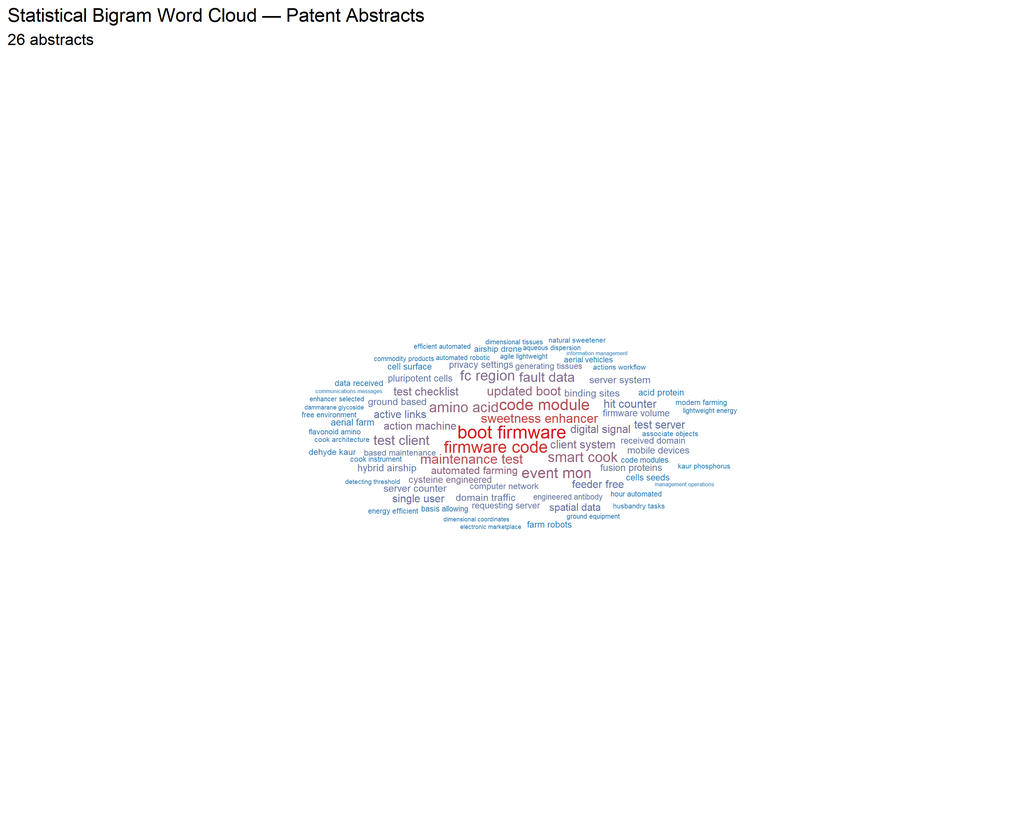

```r
top_bigrams <- bigram_counts |>
  slice_max(n, n = 80, with_ties = FALSE)

ggplot(top_bigrams, aes(label = bigram, size = n, colour = n)) +
  geom_text_wordcloud_area(rm_outside = TRUE, shape = "circle",
                           eccentricity = 0.65) +
  scale_size_area(max_size = 14) +
  scale_colour_gradient(low = "#2c7bb6", high = "#d7191c") +
  theme_minimal() +
  labs(title = "Statistical Bigram Word Cloud — Patent Abstracts",
       subtitle = paste(sum(!is.na(abstracts$abstract)), "abstracts"))
```

## 8 — AI Summary of Key Innovations (OpenAI)

Uses the OpenAI API to produce a brief paragraph summarising the most important innovations across all fetched abstracts.

```r
openai_key <- Sys.getenv("OPENAI_API_KEY", unset = "")
stopifnot("Set OPENAI_API_KEY in your .Renviron" = nchar(openai_key) > 0)

# Combine all abstracts into a single block, numbered
abstract_texts <- abstracts |>
  filter(!is.na(abstract)) |>
  mutate(entry = paste0("[", row_number(), "] ", raw, ": ", abstract)) |>
  pull(entry) |>
  paste(collapse = "\n\n")

prompt <- paste0(
  "Below are abstracts from ", sum(!is.na(abstracts$abstract)),
  " patents in the same selection.\n\n",
  abstract_texts,
  "\n\n---\n",
  "Write a single concise paragraph (150-200 words) summarising the most ",
  "important innovations represented by these patents. Focus on the key ",
  "technological themes, what problems they solve, and why they matter. ",
  "Do not list individual patents — synthesise across all of them."
)

resp <- request("https://api.openai.com/v1/chat/completions") |>
  req_headers(Authorization = paste("Bearer", openai_key),
              `Content-Type` = "application/json") |>
  req_body_json(list(
    model    = "gpt-4o-mini",
    messages = list(list(role = "user", content = prompt)),
    temperature = 0.4,
    max_tokens  = 400
  )) |>
  req_perform()

summary_text <- resp_body_json(resp)$choices[[1]]$message$content
```

### Innovation Summary

```r
cat(summary_text)
```

The collection of patents showcases significant innovations across diverse technological domains, primarily focusing on advancements in biotechnology, automated systems, and mobile technology. In biotechnology, the development of engineered antibodies and fusion proteins aims to enhance therapeutic efficacy in treating diseases, particularly cancer, by improving targeting and immune response. Automated farming technologies leverage lightweight robotic systems and UAVs to optimize agricultural practices, enabling precision farming that can significantly increase efficiency and reduce resource consumption. Additionally, mobile technology innovations facilitate dynamic coupon distribution and targeted advertising, enhancing user engagement and promoting consumer convenience. These advancements address critical challenges such as improving healthcare outcomes, enhancing food production sustainability, and optimizing marketing strategies in an increasingly digital world. Collectively, these patents reflect a trend towards more efficient, user-centric solutions that harness automation, precision, and biotechnology to meet contemporary societal needs.